# Stats 199 Research

# Exploratory Data Analysis:

```r
library(dplyr)
## Total Numeric Variables
accidents %>%
    select(Severity,
           `Distance(mi)`, # does not look significant
           `Temperature(F)`,
           `Wind_Chill(F)`,
           `Humidity(%)`,
           `Pressure(in)`, # does not look significant
           `Visibility(mi)`, # does not look significant
           `Wind_Speed(mph)`,
           `Precipitation(in)`, # does not look significant
           Total_Time) %>%
    summary()
```

```
##     Severity      Distance(mi)      Temperature(F)   Wind_Chill(F)
##  Min.   :0.000   Min.   :  0.0000   Min.   :-77.80   Min.   :-65.9
##  1st Qu.:2.000   1st Qu.:  0.0000   1st Qu.: 48.90   1st Qu.: 19.2
##  Median :2.000   Median :  0.0000   Median : 63.00   Median : 28.7
##  Mean   :2.383   Mean   :  0.2879   Mean   : 61.23   Mean   : 26.0
##  3rd Qu.:3.000   3rd Qu.:  0.0100   3rd Qu.: 75.90   3rd Qu.: 36.4
##  Max.   :4.000   Max.   :333.6300   Max.   :170.60   Max.   : 45.2
##                                     NA's   :62265    NA's   :1852370
##   Humidity(%)      Pressure(in)   Visibility(mi)   Wind_Speed(mph)
##  Min.   :  4.00   Min.   : 0.00   Min.   :  0.00   Min.   :  1.2
##  1st Qu.: 50.00   1st Qu.:29.92   1st Qu.: 10.00   1st Qu.:  5.8
##  Median : 68.00   Median :30.03   Median : 10.00   Median :  8.1
##  Mean   : 65.93   Mean   :30.04   Mean   :  9.12   Mean   :  8.8
##  3rd Qu.: 85.00   3rd Qu.:30.15   3rd Qu.: 10.00   3rd Qu.: 11.5
##  Max.   :100.00   Max.   :33.04   Max.   :140.00   Max.   :822.8
##  NA's   :64467    NA's   :57280   NA's   :71360    NA's   :442954
##  Precipitation(in)   Total_Time
##  Min.   : 0.0      Min.   :  1.217
##  1st Qu.: 0.0      1st Qu.: 29.683
##  Median : 0.0      Median : 30.833
##  Mean   : 0.1      Mean   : 94.759
##  3rd Qu.: 0.0      3rd Qu.: 59.717
##  Max.   :10.8      Max.   :400.000
##  NA's   :1979466   NA's   :4745
```

It goes against my intuition that precipitation, distance affected and visibility would not have much statistical siginificance becuase they seem like they would be the most influential factors in someones driving capabilities. You would assume that the more it rained (higher precidiptation), the driver would have harder time viewing the road or they would have a higher likelihood of hydroplaning and causing a crash. Similarly, distance and visibility go hand-in-hand that they would be important factors in causing accidents, preventing the driver from being aware of possible risks ahead.

## TMC

```r
library(ggplot2)
unique(accidents$TMC)
```

```
##  [1] 201 241 247 246 341 406 245 248 200 244 203 229 222 202 206 343 236
## [18] 239 336 339 351  NA
```

```r
# 200: multi vehicle pile up. Delays
# 201: accidents
# 202: serious accident(s)
# 203: multi-vehicle accident
# 206: fuel spillage accident(s)
# 222: accident(s). Queuing traffic
# 229: accident(s). Slow traffic
# 236: accident(s). Heavy traffic
# 239: accident(s). Traffic building up
# 241: accident(s). Right lane blocked
# 244: accident(s). Hard shoulder blocked
# 245: accident(s). Two lanes blocked
# 246: accident. Three lanes blocked
# 247: accident. Delays
# 248: accident. Delays expected
# 336: oil spillage accident(s)
# 339: jackknifed trailer(s)
# 341: jackknifed articulated lorr(y/ies)
# 343: earlier accident(s)
# 351: accident in roadworks area
# 406: entry slip road closed

# Looking to see which TMC shows up the most
summary(accidents$TMC)
```

```
##    Min. 1st Qu.  Median    Mean 3rd Qu.    Max.    NA's
##   200.0   201.0   201.0   207.4   201.0   406.0  516762
```

```r
sort(table(accidents$TMC))
```

```
##
##     351     239     336     200     341     339     206     248     236
##       6      51      62      66     361     629     857     952    1919
##     343     247     246     202     406     244     222     203     229
##    2847    4133    4739    5102    6824    8416   11576   14114   21957
##     245     241     201
##   27509  150939 1464118
```

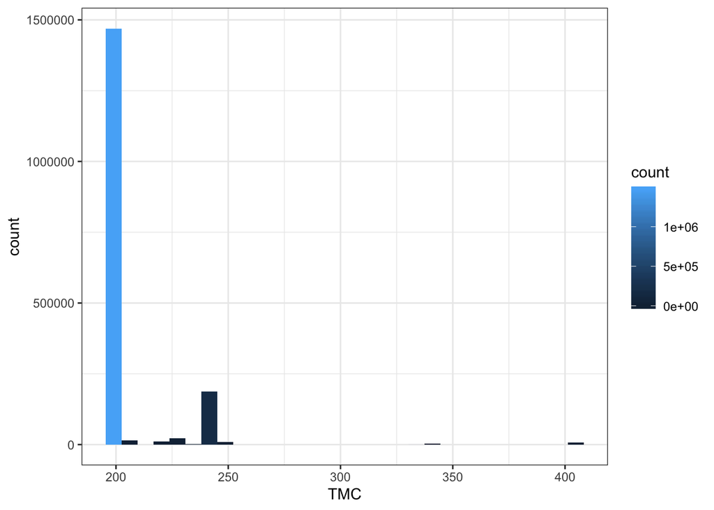

```r
ggplot(data = subset(accidents, !is.na(TMC)), aes(x = TMC)) +
  geom_histogram(aes(fill = ..count..)) +
  theme_bw()
```

We can see from the table and graphical representation of the TMC type of accident reported, that the 5 most common were: 1. 201: accident 2. 241: right lane blocked, 3. 245: Two lanes blocked, 4. 229: Slow traffic, 5. 203: multi-vehicle accdient

I find it interesting that the least amount of accidents happened in roadwork areas (351 category). This could be further investigated and even hypothesised that there were only 6 occurences becuase of *human handling*. It is no suprise that most people would slow down and be more attentive in road work areas becuase of the higher fines that go along with getting stopped in these zones. It would be very interesting to see if this would change in autonomous vehicles becuase machines do not carry the same logic that humans do, in being hyperaware when they are driving through specific zones such as roadwork areas. It would be interesting to see if autonomous vehicles would actually result in a higher count of accdients in these zones.

## Accident Signals

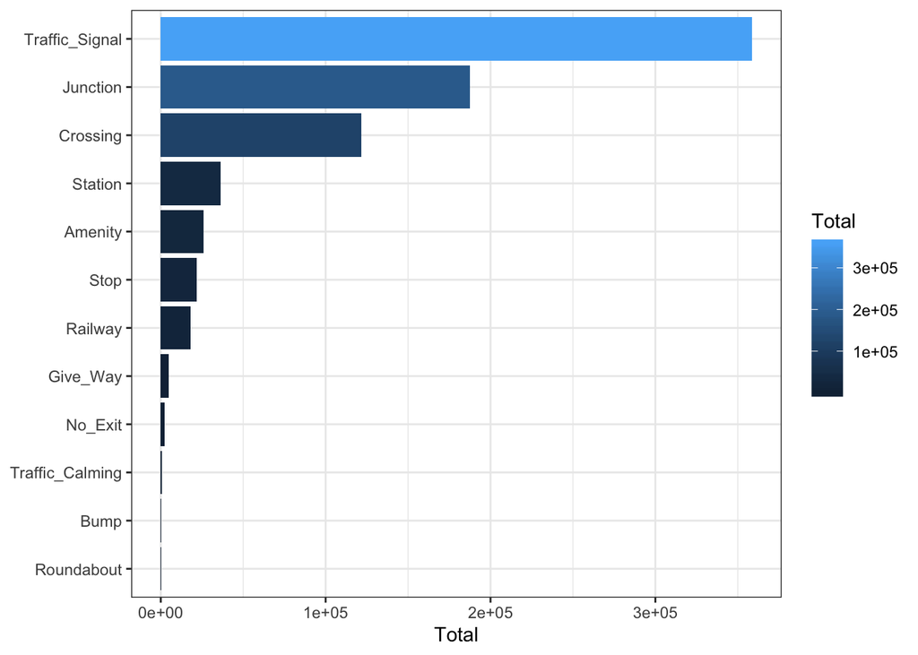

```r
library(tidyr)
library(ggplot2)
## Graphical representation
signals <- accidents %>%
    select(Amenity:Turning_Loop) %>%
    pivot_longer( cols = Amenity:Turning_Loop,
        names_to = 'Annotation',
        values_to = 'Trues') %>%
    filter(Trues == TRUE) %>%
    group_by(Annotation) %>%
    summarise(Total = n())

signals %>%
    ggplot() +
    geom_bar(aes(y = Total,
                 x = reorder(Annotation, Total, FUN = abs),
                 fill = Total),
             stat = 'identity') +
    coord_flip() +
    labs(x = NULL) +
    theme(legend.position="none") +
  theme_bw()
```

We can see that most accidents tend to happen at Traffic Signals, then Junctions, then Crossings.

This information is important when relating it to what would be the best priority when looking at autonomous vehicles. If most accidents happen at traffic signals, then we can try to see all the factors that lead into traffic signals. It is obviously important for image recognition to be able to properly tell the difference between the traffic lights, however, it is also worth thinking about WHY traffic signals have the most accidents. Psychologically speaking, it makes sense that when a driver sees a green light they are more prone to worry less about what they are doing when goign through traffic signals, because a green light simulates a “go” response. Most of the variation from traffic signal accidents must come from: - cars from the perpendicular street turning right on red and the onward traffic not slowing down because they have the right of way - cars making an unprotected left turn getting hit by oncoming traffic that also has a green light indicating they have the right of way

```r
## Severity: 1 is lesser, 4 is higher
unique(accidents$Severity)
```

```
## [1] 3 2 1 4 0
```

## Numeric Variables

Now we are going deeper into the numeric variables that could possibly have certain influence in the occurrence of accidents, due to their extreme values. Therefore, we start by observing if the extreme values (such as too cold or too hot weather) are a normal trend for the accidents to happen, or they are rather atypical values.

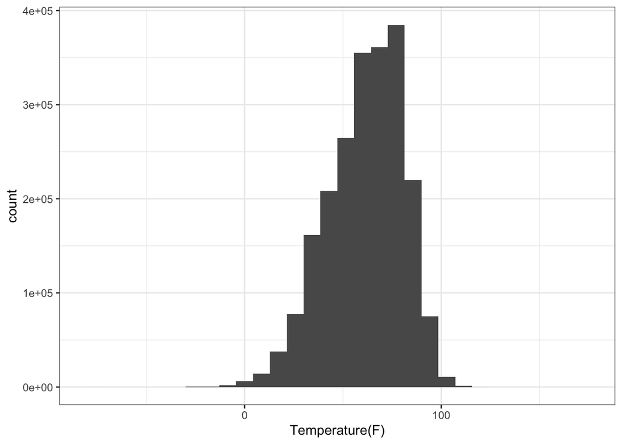

```r
library(ggplot2)
## Temperature

ggplot(accidents, aes(x =`Temperature(F)` )) +
  geom_histogram() +
  theme_bw()
```

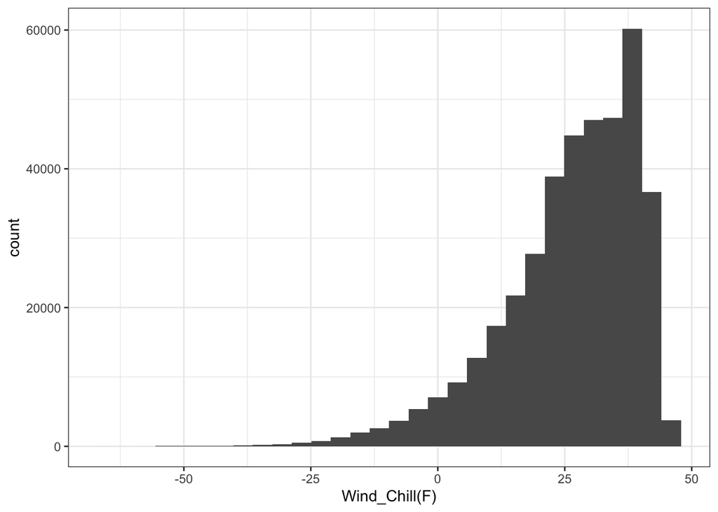

```r
library(ggplot2)
## Wind chill

ggplot(accidents, aes(x =`Wind_Chill(F)` )) +
  geom_histogram() +
  theme_bw()
```

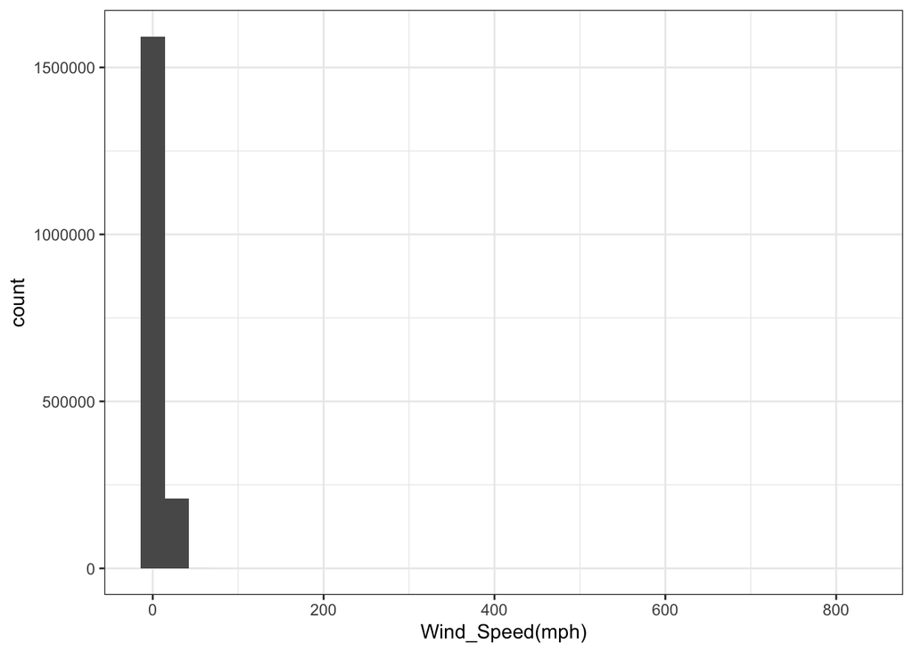

```r
library(ggplot2)
## Wind speed
ggplot(accidents, aes(x =`Wind_Speed(mph)` )) +
  geom_histogram() +
  theme_bw()
```

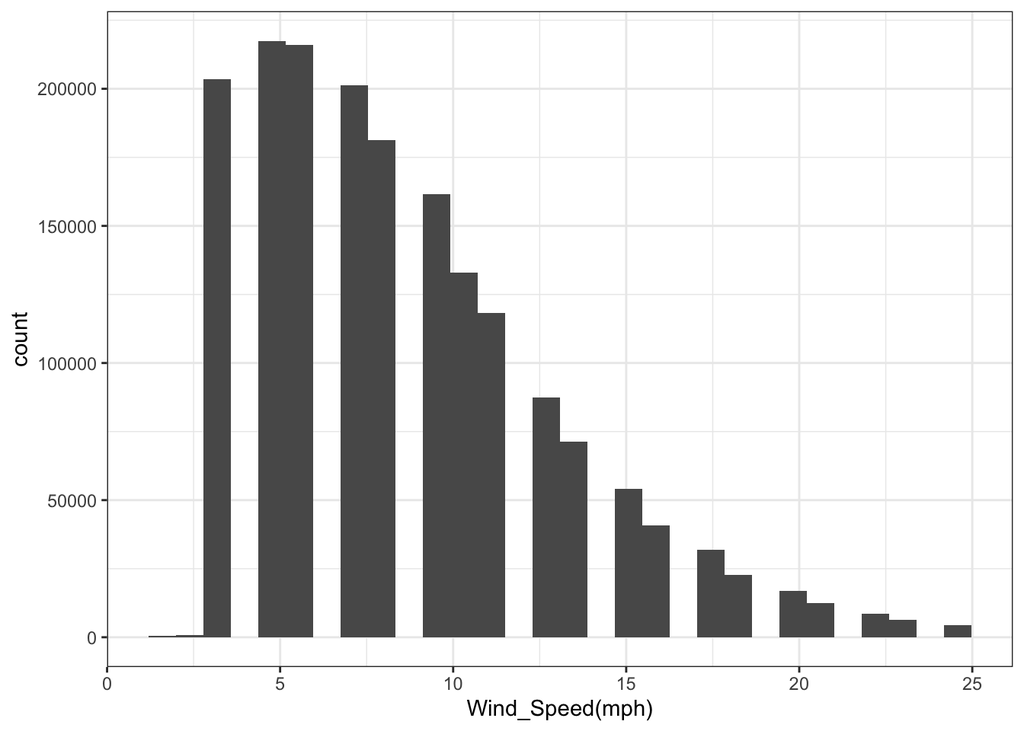

```r
accidents %>%
    select(`Wind_Speed(mph)`) %>%
    filter(`Wind_Speed(mph)` < 25) %>%
    ggplot() +
    geom_histogram(aes(x = `Wind_Speed(mph)`)) +
  theme_bw()
```

## Humidity

We want to see the baseline for humidity and then use that baseline to see how much autonomous cars can prevent accidents when implemented…

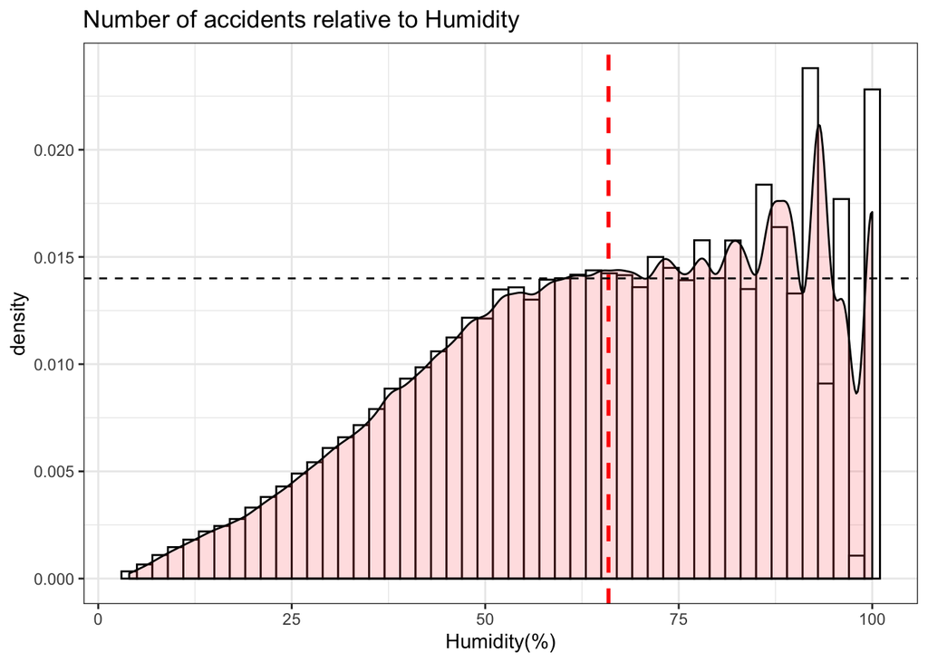

```r
library(ggplot2)
## Humidity

ggplot(data = subset(accidents, !is.na(`Humidity(%)`)), x = `Humidity(%)`) +
  geom_histogram(aes(x = `Humidity(%)`, y = ..density..), binwidth = 2, color = "black", fill = "white") +
  geom_density(aes(x = `Humidity(%)`, y = ..density..), alpha = 0.2, fill = "#FF6666") +
  theme_bw() +
  geom_vline(aes(xintercept = mean(`Humidity(%)`, na.rm = T)), color = "red", linetype = "dashed", size = 1) +
  geom_hline(yintercept = 0.014, color = "black", linetype = "dashed", size = .5) +
  ggtitle("Number of accidents relative to Humidity")
```

```r
# We can see that the median for Humidity is 68%, and the mean is 65.93%..
# When looking at the graph, we can see that the number of accidents (density) will level out at around the mean/ median scores, and then increases. We can look at the literature for why this happens, but from a statistical persepective, we can predict that autonomous vehicles will be able to decrease 27 % of accidents on the road.
# All of these predictions would be very plausible in a homogeneous system that has all working communication within all vehicles as well as with the infrastructure such as traffic signals, pedestrian crosswalk signs, etc....
```

Finding out how many accidents autonomous vehicles can prevent due to humidity:

```r
library(dplyr)
# need to find the exact count of accidents at the mean and median humidities...
sort(table(accidents$`Humidity(%)` > 65)) # 1,163,778 and  2179472 total
```

```
##
##   FALSE    TRUE
## 1015694 1163778
```

```r
1163778 / (1163778+1015694)
```

```
## [1] 0.5339724
```

```r
summary(accidents$`Humidity(%)`) # Mean 65.93
```

```
##    Min. 1st Qu.  Median    Mean 3rd Qu.    Max.    NA's
##    4.00   50.00   68.00   65.93   85.00  100.00   64467
```

```r
sort(table(accidents$`Humidity(%)`))
```

```
##
##     4     5     6     7    98     8    95     9    99    10    11    12
##   575   885  1214  1648  1708  2216  2462  2565  2952  3014  3375  3785
##    13    14    15    16    17    19    18    20    21    22    23    24
##  4129  4592  4988  5242  5443  5999  6109  6966  7469  7928  8654  8850
##    25    91    26    27    28    29    30    31    32    34    33    36
##  9871 10101 10140 11205 11363 12290 12850 13697 13863 14801 14864 16282
##    35    37    39    92    40    38    42    41    43    85    45    44
## 16395 18184 18523 19034 19718 20093 20853 20933 22097 22642 22696 23497
##    47    46    80    51    49    56    48    50    71    54    64    53
## 24366 24654 25184 25909 26146 26617 26881 26951 27447 28404 28443 28448
##    66    60    77    75    58    62    57    68    97    52    55    88
## 28687 28828 28964 29108 29198 29746 30089 30125 30318 30327 30801 31345
##    69    59    76    70    79    63    61    86    73    72    67    83
## 31555 31574 31695 31794 31971 32031 32201 32257 32463 32913 33369 33533
##    74    65    82    81    84    78    94    89    96    87    90    93
## 34052 34219 35201 35893 36219 36802 37191 40106 46839 47820 47853 84731
##   100
## 99444
```

```r
34219 + 35201 + 35893 + 36219 + 36802 + 37191 + 40106 + 46839 + 47820 + 47853 + 84731 + 99444
```

```
## [1] 582318
```

```r
# 582,318

582318 / 2179472
```

```
## [1] 0.2671831
```

# Weather_Condition

### EDA with `Weather_Conditions`

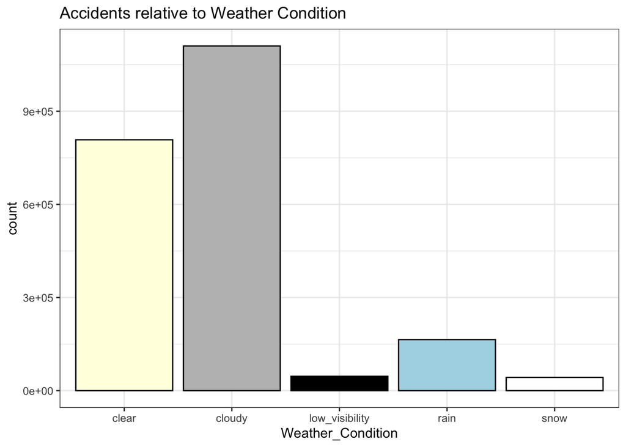

```r
library(ggplot2)
ggplot(data = subset(accidents, !is.na(Weather_Condition)) , aes(x = Weather_Condition)) +
  geom_bar(color = "black", fill = c("light yellow", "grey", "black", "light blue", "white")) +
  theme_bw() +
  ggtitle("Accidents relative to Weather Condition")
```

```r
library(xtable)
options(xtable.comment = FALSE)
options(xtable.timestamp = "")
wctbl <- sort(table(accidents$Weather_Condition))
xtable(wctbl)
```

```
## \begin{table}[ht]
## \centering
## \begin{tabular}{rr}
##   \hline
##  & V1 \\
##   \hline
## snow & 42810 \\
##   low\_visibility & 46278 \\
##   rain & 164604 \\
##   clear & 808182 \\
##   cloudy & 1110061 \\
##    \hline
## \end{tabular}
## \end{table}
```

# States

Now we can explore a little bit the accidents in different states: - which state has the main occurrence of accidents? - Which one the most severe ones? - Is there a relationship with the traffic lights or the humidity as we discovered early?

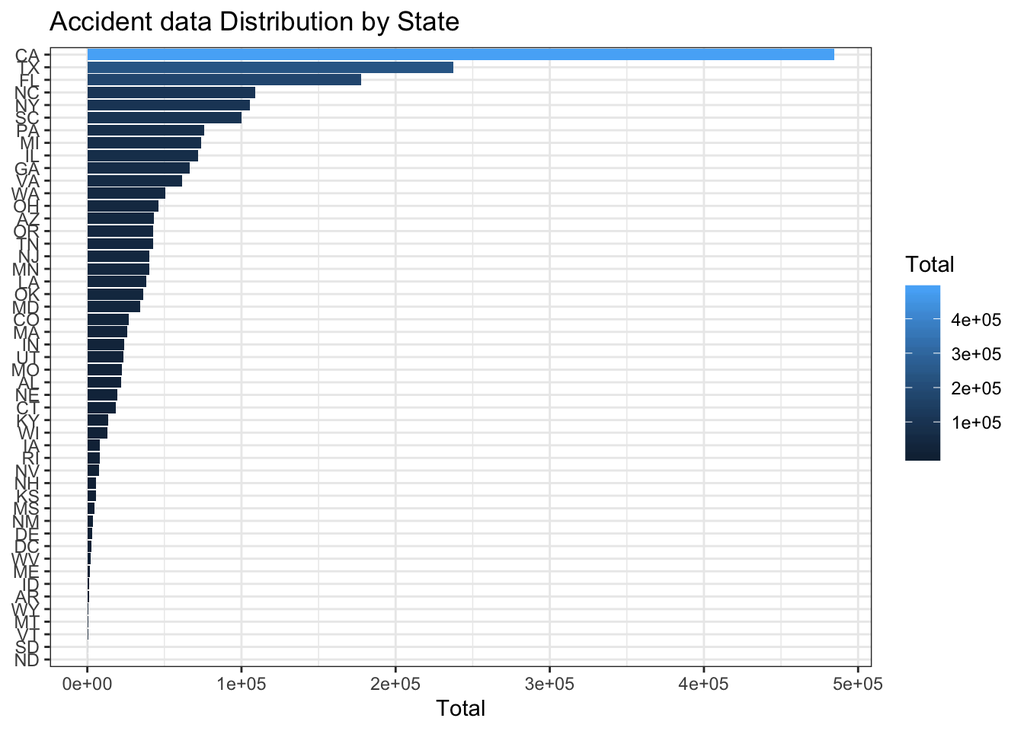

```r
library(ggplot2)
# Amount of accidents per state
accidents %>%
    select(State) %>%
    group_by(State) %>%
    summarise(Total = n()) %>%
    ggplot() +
    geom_bar(aes(y = Total,
                 x = reorder(State, Total, FUN = abs),
                 fill = Total),
             stat = 'identity') +
    coord_flip() +
    labs(x = NULL) +
    theme(legend.position="none") +
  theme_bw() +
  ggtitle("Accident data Distribution by State")
```

We can see that California has the most amount of total accidents, but that may be simply because they have the most drivers compared to the other states, so we need to look at the proportions, of the accidents to the total drivers in the state

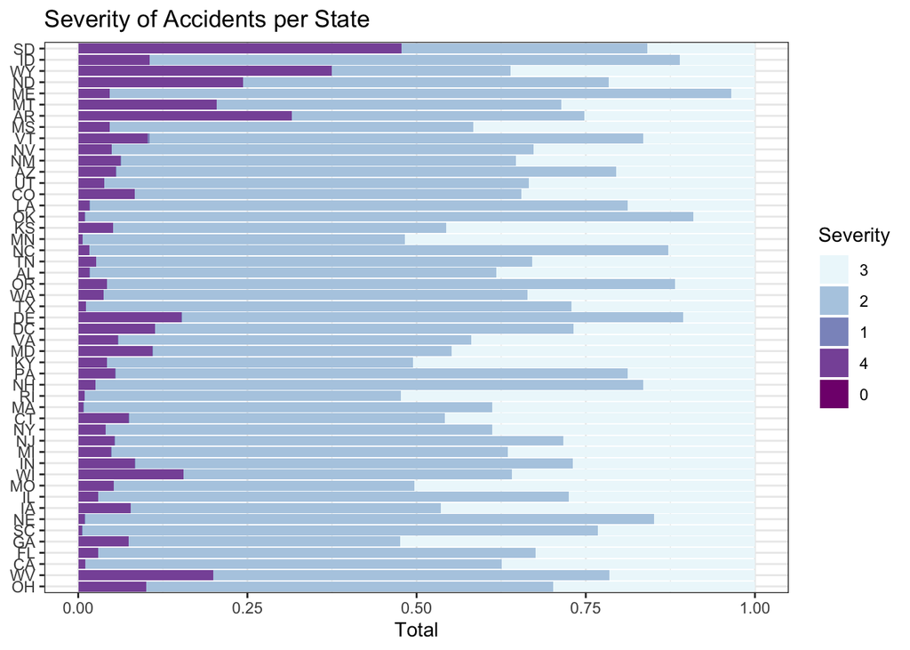

```r
library(readr)
library(ggplot2)
## Amount per state/severity, proportional as found by Manuel T.
accidents %>%
     select(Severity, State) %>%
     mutate(State = parse_factor(State),
            Severity = parse_factor(as.character(Severity))) %>%
     group_by(State, Severity) %>%
     summarise(Total = n()) %>%
     ggplot() +
     geom_bar(aes(y = Total,
                  x = State,
                  fill = Severity),
              stat = 'identity',
              position = 'fill') +
     coord_flip() +
     scale_fill_brewer(palette = 'BuPu') +
     labs(x = NULL) +
   theme_bw() +
   ggtitle("Severity of Accidents per State")
```

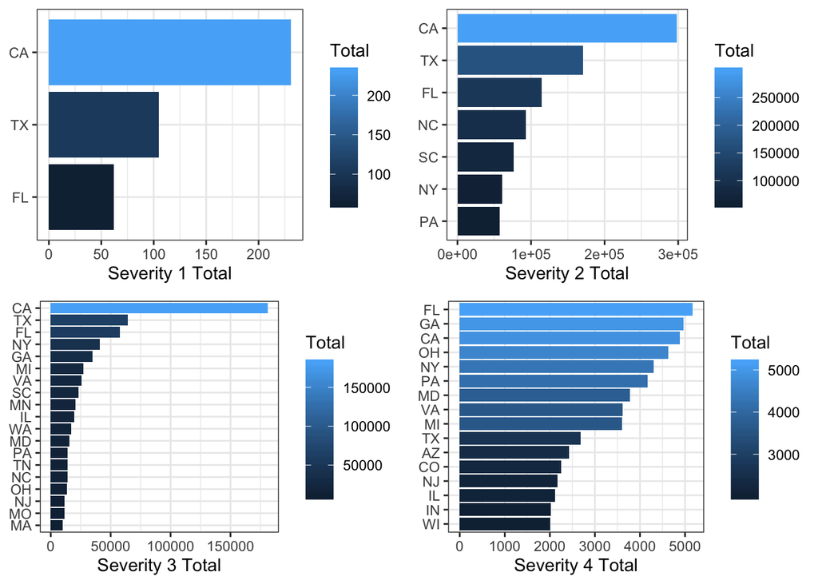

```r
 library(cowplot)
 ## Function created by Manuel T.
plot_SevState <- function(sev, min = 10000) {
     accidents %>%
         select(State, Severity) %>%
         filter(Severity == sev) %>%
         group_by(State) %>%
         summarise(Total = n()) %>%
         filter(Total > min) %>%
         ggplot() +
         geom_bar(aes(y = Total,
                      x = reorder(State, Total, FUN = abs),
                      fill = Total),
                  stat = 'identity') +
         coord_flip() +
         labs(x = NULL, y = paste("Severity", sev, "Total")) +
         theme(legend.position="none") +
     theme_bw()
 }

 ## Visualization
 plot_grid(
     plot_SevState(1, min = 50),
     plot_SevState(2, min = 50000),
     plot_SevState(3),
     plot_SevState(4, min = 2000))
```

Taking a closer look at CA, TX, FL:

```r
library(dplyr)
# CA
filter(accidents, State == "CA") %>%
    select(Amenity:Turning_Loop) %>%
    summary()
```

```
##   Amenity           Bump          Crossing        Give_Way
##  Mode :logical   Mode :logical   Mode :logical   Mode :logical
##  FALSE:481563    FALSE:484676    FALSE:475619    FALSE:484525
##  TRUE :3143      TRUE :30        TRUE :9087      TRUE :181
##   Junction        No_Exit         Railway        Roundabout
##  Mode :logical   Mode :logical   Mode :logical   Mode :logical
##  FALSE:420390    FALSE:484495    FALSE:479325    FALSE:484694
##  TRUE :64316     TRUE :211       TRUE :5381      TRUE :12
##   Station           Stop         Traffic_Calming Traffic_Signal
##  Mode :logical   Mode :logical   Mode :logical   Mode :logical
##  FALSE:476064    FALSE:478652    FALSE:484655    FALSE:453662
##  TRUE :8642      TRUE :6054      TRUE :51        TRUE :31044
##  Turning_Loop
##  Mode :logical
##  FALSE:484706
##
```

```r
# TX
filter(accidents, State == "TX") %>%
    select(Amenity:Turning_Loop) %>%
    summary()
```

```
##   Amenity           Bump          Crossing        Give_Way
##  Mode :logical   Mode :logical   Mode :logical   Mode :logical
##  FALSE:233331    FALSE:237606    FALSE:226295    FALSE:236399
##  TRUE :4306      TRUE :31        TRUE :11342     TRUE :1238
##   Junction        No_Exit         Railway        Roundabout
##  Mode :logical   Mode :logical   Mode :logical   Mode :logical
##  FALSE:223911    FALSE:237362    FALSE:235446    FALSE:237631
##  TRUE :13726     TRUE :275       TRUE :2191      TRUE :6
##   Station           Stop         Traffic_Calming Traffic_Signal
##  Mode :logical   Mode :logical   Mode :logical   Mode :logical
##  FALSE:234136    FALSE:236505    FALSE:237591    FALSE:173672
##  TRUE :3501      TRUE :1132      TRUE :46        TRUE :63965
##  Turning_Loop
##  Mode :logical
##  FALSE:237637
##
```

```r
# FL
filter(accidents, State == "FL") %>%
    select(Amenity:Turning_Loop) %>%
    summary()
```

```
##   Amenity           Bump          Crossing        Give_Way
##  Mode :logical   Mode :logical   Mode :logical   Mode :logical
##  FALSE:176839    FALSE:177488    FALSE:160362    FALSE:177315
##  TRUE :651       TRUE :2         TRUE :17128     TRUE :175
##   Junction        No_Exit         Railway        Roundabout
##  Mode :logical   Mode :logical   Mode :logical   Mode :logical
##  FALSE:165728    FALSE:177282    FALSE:176935    FALSE:177462
##  TRUE :11762     TRUE :208       TRUE :555       TRUE :28
##   Station           Stop         Traffic_Calming Traffic_Signal
##  Mode :logical   Mode :logical   Mode :logical   Mode :logical
##  FALSE:171480    FALSE:177004    FALSE:177464    FALSE:129756
##  TRUE :6010      TRUE :486       TRUE :26        TRUE :47734
##  Turning_Loop
##  Mode :logical
##  FALSE:177490
##
```

# Time

Now taking a look at accidents per hour

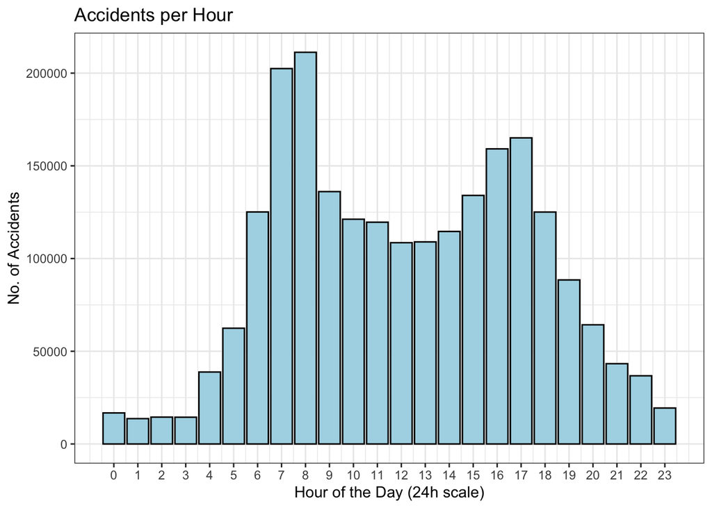

```r
library(ggplot2)
library(lubridate)
ggplot(US_Accidents_May19, aes(x = hour(Start_Time))) +
  geom_histogram(stat = 'count', color = "black", fill = "light blue") +
  theme_bw() +
  labs(x = "Hour of the Day (24h scale)", y = "No. of Accidents") +
  ggtitle("Accidents per Hour") +
  scale_x_continuous(breaks = seq(0, 23, by = 1))
```

We can see from the graph above that the accidents distribution tend to be bimodal, with most of them happening around 7-8am and then 4-5pm which would follow our intuition becuase that is when the majority of people commute to and from work, resulting in rush hour and navigating with more drivers and traffic than the other hours.

One thing that stands out to me is that most of the accidents would happen in the morning rush hour times as opposed to the afternoon rush hour times becuase in other studies it has been found that most accidents tend to happen on our way’s from work becuase we are more tired and irritable than in the morning when we are fresh.

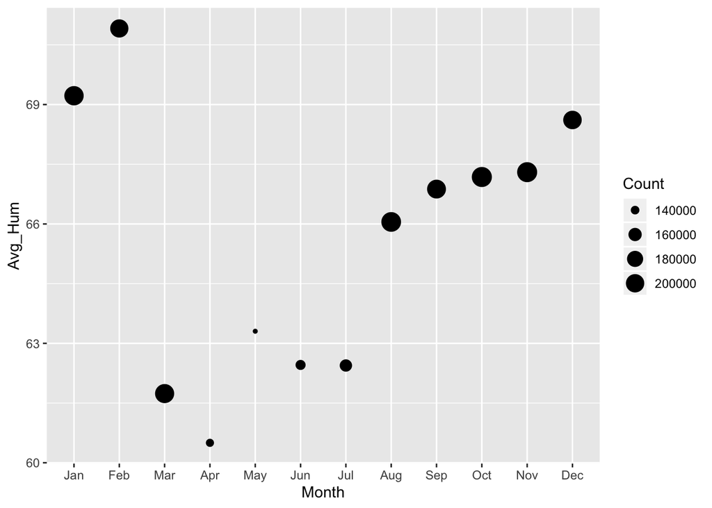

```r
library(dplyr)
library(ggplot2)
## Month and humidity as visualized by Manuel T.
US_Accidents_May19 %>%
    select(Start_Time, `Humidity(%)`) %>%
    mutate(Month = month(Start_Time,
                            label = T)) %>%
    group_by(Month) %>%
    summarise(Avg_Hum = mean(`Humidity(%)`, na.rm = T),
              Count = n()) %>%
    ggplot(aes(x = Month, y = Avg_Hum)) +
    geom_point(aes(size = Count))
```

This graph is very telling in the relationship between the humidity and and the count of accidents because we can see that in the months where there is higher avg. humidity, there is also a higher count of accidents: an example would be to look at the month of February, which has high avg. humidity and also high counts, and compare it to the month of May where ther is lower avg. humidity and lower counts. This relationship however is not linear in any sense becuase months like March can be outliers in the data becuase there tends to be lower avg. humidity and relatively higher counts of accidents as well.

#Word Cloud:

Creating the word cloud : initially I tried to create a term-document matrix, however I woudl get an error stating that my computer has reached it maximum memory limit, so I was not able to move forward with that method. I did some research and found this to be the most effective method for my purposes.

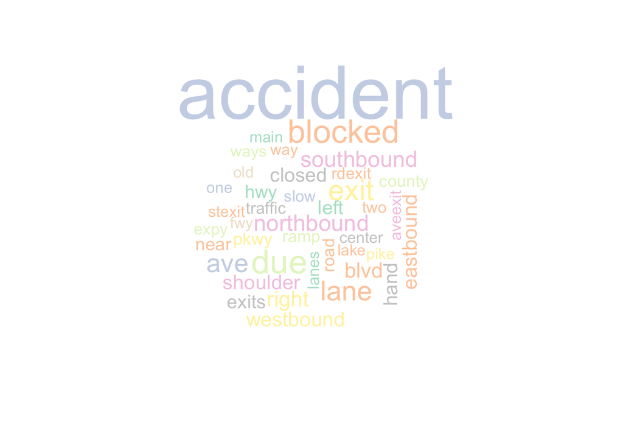